# Tidy Data

Author

Sepehr Akbari

Published

October 11, 2024

## Setup

Loading required libraries and the `airport_data_speeds` dataset.

```r
library(tidyverse)
library(readxl)
library(gt)

airport_data_speeds <- read_excel(file.path(base_dir, "Data/airport_data_speeds.xlsx"))
```

## Problem 1

**The actual variables:**

- Year: The year of construction (e.g 2018)
- Month: The month of construction (e.g June)
- 1 unit: The number of constructions that had 1 unit
- 2 to 4 units: The number of constructions that had 2-4 units
- 5 units or more: The number of constructions that had more than 5 units
- Northeast: The number of constructions that took place in the northeast region
- Midwest: The number of constructions that took place in the midwest region
- South: The number of constructions that took place in the southern region
- West: The number of constructions that took place in the western region

**Tidy dataset’s format**:

- Year: The year of construction (e.g 2018)
- Month: The month of construction (e.g June)
- Scale/Size: How many units the construction has/had (e.g 1 unit)
- Scale Count: Count of the construction by month
- Region: The region where the construction is/was taking place (e.g Midwest)
- Region Count: Count of the construction by region

```r
construction_tidy <- construction %>%
  pivot_longer(
    cols = `1 unit`:`5 units or more`,
    names_to = "Scale",
    values_to = "Scale Count"
  ) %>%
  pivot_longer(
    cols = Northeast:West,
    names_to = "Region",
    values_to = "Region Count"
  )

glimpse(construction_tidy)
```

```
Rows: 108
Columns: 6
$ Year           <dbl> 2018, 2018, 2018, 2018, 2018, 2018, 2018, 2018, 2018, 2…
$ Month          <chr> "January", "January", "January", "January", "January", …
$ Scale          <chr> "1 unit", "1 unit", "1 unit", "1 unit", "2 to 4 units",…
$ `Scale Count`  <dbl> 859, 859, 859, 859, NA, NA, NA, NA, 348, 348, 348, 348,…
$ Region         <chr> "Northeast", "Midwest", "South", "West", "Northeast", "…
$ `Region Count` <dbl> 114, 169, 596, 339, 114, 169, 596, 339, 114, 169, 596, …
```

As we can see by the results above, the dataset is tidy, but the rows still don’t represent an obervation, because of how the data was collected.

## Problem 2

Tidying the data:

```r
airport_data_speed_tidy <- airport_data_speeds %>%
  pivot_longer(
    cols = !`AIRPORT CODE`,
    names_to = "Carrier",
    values_to = "Speed"
  )

glimpse(airport_data_speed_tidy)
```

```
Rows: 200
Columns: 3
$ `AIRPORT CODE` <chr> "RSW", "RSW", "RSW", "RSW", "ORD", "ORD", "ORD", "ORD",…
$ Carrier        <chr> "VERIZON", "SPRINT", "AT&T", "T-MOBILE", "VERIZON", "SP…
$ Speed          <dbl> 38.5, 13.0, 9.7, 8.6, 55.6, 30.4, 8.2, 7.0, 22.4, 15.2,…
```

Plotting the data:

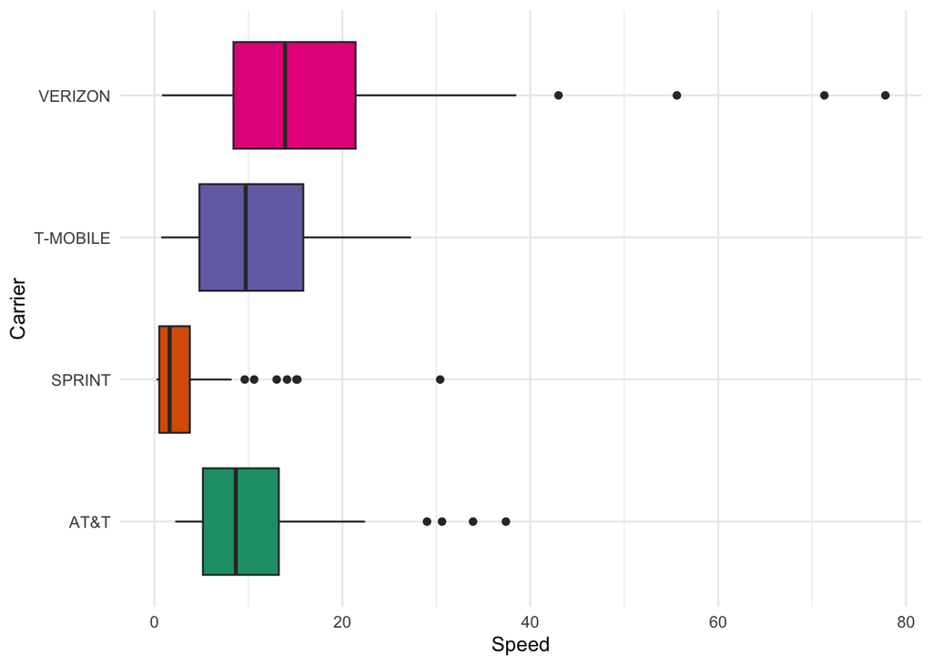

```r
ggplot(
  airport_data_speed_tidy,
  aes(
    x = Speed,
    y = Carrier,
    fill = Carrier
  )
) +
  geom_boxplot(show.legend = FALSE) +
  theme_minimal() +
  scale_fill_brewer(palette = "Dark2")
```

## Problem 3

I’ll use `group_by()`, and `max()` to get only the highest speed in each airport, and then just use `filter()` to only show the rows with Verizon as their carrier.

```r
airport_data_speed_tidy %>%
  group_by(`AIRPORT CODE`) %>%
  filter(Speed == max(Speed)) %>%
  ungroup() %>%
  filter(Carrier == "VERIZON") %>%
  count(Carrier) %>%
  gt()
```

| Carrier | n |
| --- | --- |
| VERIZON | 21 |

So, Verizon has the highest speed in 21 airports.